# The Bok Stops Here

Springbok Tests and the South African economy, 1995–2026

Author

Affiliation

Cesaire Tobias

Sheet Solved

Published

25 November 2026

**NoteRead this first**

This paper was written just for fun, by a South African rugby fan. The data and sources are real, and the whole document can be reproduced from the code and data snapshots in the repository at github.com/ces0491/springbok-economy by following the steps in Section 9.

**Abstract.** Does anything in the South African economy move when the Springboks play? This paper puts that one question to three outcomes on three timescales: the rand over the weekend of a Test, real sales over the month at restaurants, takeaways and caterers, at butchers and bottle stores and at general dealers, and real GDP over the quarter. The same regression is fitted to each, with the number of Springbok Tests in the period as the variable of interest and the season and the year held fixed. A Test changes the rand’s weekend return by 2.5 basis points (95% CI −8.6 to 13.6), real bar sales in its month by 0.34% (−0.42 to 1.10), sales at butchers, bottle stores and other specialised food and drink retailers by 0.00% (−0.43 to 0.44) and GDP growth in its quarter by −0.06 percentage points (−0.16 to 0.04). None of these can be told from zero, and neither can the estimates for food sales and general dealers. The bar series that shows no rugby rose 18% in June 2010, when South Africa hosted the football World Cup. Winning rather than losing makes no measurable difference either: the rand is 14.8 basis points weaker after a win than after a loss (−32.6 to 2.9). One estimate does stand out, and it comes before a ball is kicked. The rand is 17.5 basis points weaker on the Friday before a Test weekend than on other Fridays (p = 0.003), which the paper cannot explain. The weeks after the 2007 and 2019 finals did see large rand rallies, and both coincide with unrelated financial news. One regression in the paper finds that each World Cup title has cost the rand 32% of its value against the dollar; Section 5.7 explains why it should be ignored.

**JEL codes:** Z20, F31, G14, G41, E32. **Keywords:** rugby, exchange rates, consumer spending, output, event study, sports sentiment, randomisation inference.

# 1 Introduction

South Africa takes its rugby seriously. When the Springboks won the 2023 Rugby World Cup, the President declared 15 December 2023 a public holiday (Ramaphosa, 2023; The Presidency, 2023). During the 2023 tournament, a professor in North-West University’s Faculty of Economic and Management Sciences explained that “when a country’s team loses, investors are somewhat depressed, and the next day is often a bad one on the stock exchange”, adding that research had found this “for the FIFA World Cup and international cricket and rugby matches” (Inside Education, 2023). In 2015 a Standard Bank blog post reported that after the 2007 final “the rand strengthened by 4.3% against the US dollar and managed to gain 7.0% against the pound in the week following the victory” (Standard Bank, 2015).

My question, however, was less about whether the Boks win or lose. What I wanted to know is whether anything in the economy moves when the Springboks play, regardless of the result. A Test is an occasion before it is a result. People buy brandy and braai meat ahead of it and fill bars during it, whoever wins, and if the claims above are right they trade the rand differently after it. If any of that adds up to something, the periods that hold a Test match should look different from the ones that do not.

The paper puts the question to three outcomes at three timescales. The rand answers within a weekend. Most Tests are played on a Saturday or Sunday, when the currency market is closed, so the Friday and Monday noon fixes in New York bracket the match exactly. Spending answers within a month, in Statistics South Africa’s surveys of real food and bar sales at restaurants, takeaways and caterers, and of real sales at butchers, bottle stores and general dealers. Output answers within a quarter. The same regression is run on each, with the number of Tests in the period as the variable of interest, and the estimate in each case is the percentage change in the outcome from one more Test. A second version splits the Tests into wins and losses and asks whether the result matters on top of the occasion.

The answer is the same on all three timescales (Table 4). A Test weekend’s return on the rand differs from other weekends’ by 2.5 basis points, with a 95% confidence interval from −8.6 to 13.6. One more Test in a month changes real bar sales by 0.3% (−0.4 to 1.1) and sales at butchers and bottle stores by 0.0%. One more Test in a quarter goes with −0.06 percentage points of GDP growth (−0.16 to 0.04). Winning rather than losing changes none of the six outcomes measurably.

Spending does spike on match days. Bank card data show it: after the 2023 final, spending by Discovery Bank’s clients in South Africa was three times that of an average Saturday night (Discovery Bank, 2023). Whether a spike adds anything to the economy depends on whether the money would otherwise have been spent later in the month, on something else or somewhere else. A monthly total can tell the difference, and it shows nothing. The same bar series rose 18% in the month South Africa hosted the 2010 football World Cup, so it can see an event when there is one.

One estimate stands out, and it is in the wrong place. On the Friday before a Test weekend the rand is 17.5 basis points weaker than on other Fridays (p = 0.003). No match has been played by then and the fixture has been known for months. The paper reports it in Section 5.3 and has no explanation for it.

The usual evidence for a Springbok effect is the rand’s rally after a World Cup final. Five days after the 2007 final, on Thursday 25 October, the Industrial and Commercial Bank of China agreed to pay R36.7 billion for a fifth of Standard Bank, a record for foreign direct investment into South Africa (Allen, 2007; Laing, 2007). Standard Bank had told the market two days earlier that talks were under way (Allen, 2007). Over that week the rand outpaced the emerging-market basket by 4.2 percentage points. The bank’s own deal is a better candidate for the rally than the rugby.

# 2 Related work

Much of the work on national sporting results and asset prices is about football and stock markets. Ashton, Gerrard and Hudson (2003) found a strong association between England’s results and the next day’s FTSE 100 return. A replication found mistakes in the empirical set-up (Klein, Zwergel and Fock, 2009), and the original authors later reported that the link had weakened after 2002 (Ashton, Gerrard and Hudson, 2011). The best-known study, Edmans, García and Norli (2007), found a next-day stock market decline of 49 basis points after a loss in the elimination stage of the football World Cup. Their rugby sample covers seven nations including South Africa, which contributes 27 wins and 25 losses. Rugby losses were followed by abnormal returns of −9.5 basis points with a t-statistic of −1.74, wins by −8.6 basis points, and the authors describe the rugby evidence as marginal (their Tables V and AI, and p. 1984). Kaplanski and Levy (2010) found weaker US stock returns during football World Cups, and Ehrmann and Jansen (2016) showed that prices fall during a match when the home side is about to lose. A meta-analysis of 37 football studies found that the loss effect for national teams shrinks to about −5 basis points and becomes insignificant once publication bias is corrected for (Geyer-Klingeberg *et al.*, 2018).

Rugby-specific evidence is thinner, and mostly null. Boyle and Walter (2003) found that New Zealand’s stock market behaves independently of the All Blacks. Two South African studies tested the JSE All Share Index against Springbok results. Smith and Krige (2010) found no significant win or loss effect for rugby, and Botha and De Beer (2013) found the rugby win and loss coefficients insignificant at all conventional levels. Gerlach (2011) showed that abnormal returns after national team matches also appear in comparable countries that did not play, which is why this paper nets out a benchmark of other currencies.

Exchange rates have had less attention. Two studies of Turkey find opposite signs: the lira weakened after club football wins against foreign sides (Eker, Berument and Dogan, 2007) and strengthened after national team wins (Demir, Lau and Fung, 2014). The literature search for this paper found no study of rugby and the rand. Beyond markets, Kavetsos and Szymanski (2010) found that hosting a football tournament raises reported happiness while national sporting success has no significant effect, and Baade and Matheson (2004) estimated that the US host cities of the 1994 football World Cup suffered cumulative losses of $5.5 billion to $9.3 billion.

Spending is where the literature studies the occasion more than the result, and the question there is displacement. Studies of US cities find that much of the money spent on sport is money not spent on something else. Coates and Humphreys (2003) found that professional sports raise earnings in amusement and recreation in US cities and lower them in other sectors. Coates and Depken (2011) found, in monthly sales-tax data for Texas cities, that regular-season and many post-season games coincided with net falls in economic activity, and Baade, Baumann and Matheson (2008) found that new stadiums, franchises and mega-events in Florida were as likely to reduce taxable sales as to raise them. Among students at one US university, high-profile football game days rank with New Year’s Eve among the heaviest drinking days (Neal and Fromme, 2007), but Bank of Ireland’s card data show Irish pub spending falling in September 2023, during Ireland’s World Cup pool games, while its customers’ spending in France rose. That comparison is with August, and the bank notes that September spending also fell in 2021 and 2022 (Bank of Ireland, 2023). Before the 2019 final, Business Insider SA predicted that liquor outlets would sell more if the Springboks lost, quoting a University of Pretoria psychologist on research showing that drinking rises on days of big sporting events (de Villiers, 2019).

This paper asks one question of the rand, of South African spending and of output, with the same regression on each. It adds 363 Test weekends over 31 years, a design that needs no kick-off times, a monthly test of whether match-day spending is new money, and statements of the effect sizes the data can rule out, which a null result needs in order to mean anything.

# 3 Data

Table 1 lists the sources. The paper renders from snapshots of each, stored with their SHA-256 hashes in the repository, and refuses to run if a snapshot has changed.

Table 1: Data sources

| Variable | Source | Frequency | Sample |
| --- | --- | --- | --- |
| Springbok Test results | World Rugby match list | Per match | 1992–2026 |
| Second results source (cross-check) | Author’s results database (ESPN and a historical import) | Per match | 1992–2026 |
| Rand per US dollar | Federal Reserve H.10, via FRED (DEXSFUS) | Daily (US business days) | Mar 1995 to Nov 2026 |
| Benchmark currencies per US dollar | H.10 via FRED: real, peso, rupee, won, baht | Daily | As for the rand |
| Bar and food income, real | Stats SA Food and beverages survey (P6420) | Monthly | Jan 2008 to Aug 2026 |
| Retail sales by type of retailer, real | Stats SA Retail trade sales (P6242.1) | Monthly | Jan 2008 to Sep 2026 |
| Real and nominal GDP | IMF International Financial Statistics, via FRED | Quarterly, seasonally adjusted | 1993Q1 to 2026Q1 |

*Sources:* World Rugby (2026); Tobias (2026); Board of Governors of the Federal Reserve System (2026); Statistics South Africa (2026a); Statistics South Africa (2026b); International Monetary Fund (2026). Retrieved 25 November 2026. The analysis of Statistics South Africa’s data is my own independent processing of it.

**Tests.** World Rugby’s list holds 477 Springbok entries from 1992 onwards, including tour matches against provinces, clubs, A sides, the Barbarians and World XVs. Pontypridd and the Hanan Shield Districts are in there. A match counts as a Test here when the opponent is the senior national side of a World Rugby member union or the British & Irish Lions, which leaves 406 Tests. Each was paired with a results database I compiled separately, mostly from ESPN’s scoreboard and an older historical import (Tobias, 2026). 19 of its Tests, among them the 1997, 2009 and 2021 Lions series, are recorded in it as coming from World Rugby itself, so for those the comparison below is not independent. All 406 Tests pair one to one, 2 of them a day apart because an evening kick-off in the Americas falls on the next UTC day. The two sources disagree on one score: World Rugby has the Springboks scoring 27 in the 22–38 loss to Australia at Ellis Park on 16 August 2025, against 22 in the database and in match reports (Williamson, 2025). The correction is recorded in the repository, and the result is a loss either way. World Rugby’s labels for World Cup stages agree with the tournament format in all 50 World Cup matches, and its four finals won are the four in Table 10. A Test counts as a home Test when World Rugby’s venue is in South Africa. For the 2 Tests where it lists no venue, the second database’s home side decides; neither is one it took from World Rugby.

World Rugby’s kick-off times are unreliable for older matches. Several Tests in Australia are listed at 8pm UTC, which would be early the next morning local time. The design below does not use kick-off times.

**Exchange rates.** The rand series is the Federal Reserve’s noon buying rate in New York, in rand per US dollar (Board of Governors of the Federal Reserve System, 2026). The sample starts on 13 March 1995, the day South Africa replaced its dual commercial and financial rand with one exchange rate (Liebenberg, 1995). Returns are log changes between consecutive fixes, multiplied by −100, so that a positive number means a stronger rand. The benchmark is an equal-weighted basket of five emerging-market currencies whose countries are not tier-one rugby nations: the Brazilian real, Mexican peso, Indian rupee, South Korean won and Thai baht. Australia, New Zealand, Japan, the UK and the euro area are left out because their own teams’ results could move their currencies.

**Spending.** Statistics South Africa’s monthly survey of the food and beverages industry reports income from bar sales and from food sales separately, across restaurants and coffee shops, takeaway and fast-food outlets, and caterers (Statistics South Africa, 2026a). The industry total is the sum of those three types of business, and pubs and taverns are not among them, so bar sales here are the drinks sold by restaurants, takeaways and caterers. Its retail trade survey reports sales by type of retailer, including “retailers of food, beverages and tobacco in specialised stores” and general dealers (Statistics South Africa, 2026b). The specialised-store category is industry group 6220, which includes butchers and bottle stores (Republic of South Africa, 2010): the braai end of the market. General dealers are the non-specialised stores, among them those in which food, beverages and tobacco dominate (Republic of South Africa, 2010), which is where a supermarket falls. All four series are at constant prices and not seasonally adjusted, and they start in January 2008, the first month for which Stats SA publishes them at constant prices. Months from March 2020 to December 2021 are left out. Trading restrictions, curfews and bans on alcohol sales during the pandemic (Moultrie *et al.*, 2021) took bar income to zero in April and May 2020, and sales in those months followed lockdown rules, whatever the rugby. That leaves 202 months for bar sales, in which the Springboks played 206 Tests.

**GDP.** Real GDP is the seasonally adjusted quarterly series for South Africa in the IMF’s International Financial Statistics (International Monetary Fund, 2026). Growth is the quarter-on-quarter log change in percent, from 1993Q2 to 2026Q1. Its mean is 0.56% and its standard deviation 2.09%, or 0.68% without the COVID-19 collapse and rebound of 2020Q2 and 2020Q3. Those two quarters are left out of the regressions, which leaves 130 quarters holding 389 Tests.

Table 2: Weekend returns by Springbok Test, March 1995 to November 2026 (basis points)

| Weekend | Weekends | Rand mean | Rand s.d. | Rand min | Rand max | Basket mean |
| --- | --- | --- | --- | --- | --- | --- |
| With a Test | 363 | -4.6 | 94.3 | -372.3 | 536.6 | -7.4 |
| of which won | 232 | -7.5 | 98.8 | -372.3 | 536.6 | -6.5 |
| of which lost | 124 | 2.9 | 86.8 | -302.2 | 267.6 | -8.7 |
| of which drawn | 7 | -43.4 | 53.9 | -108.9 | 49.2 | -14.6 |
| Without a Test | 1,278 | -4.8 | 97.3 | -493.3 | 483.4 | -3.8 |
| All weekends | 1,641 | -4.8 | 96.6 | -493.3 | 536.6 | -4.6 |

*Notes:* A weekend’s return runs from the last noon fix before Saturday to the first noon fix after Sunday, usually Friday to Monday. Positive values mean a stronger currency against the US dollar. The basket is the equal-weighted mean of the real, peso, rupee, won and baht over the same dates. 12 weekends that overlap the price window of a weekday Test are excluded.

Table 2 describes the 1,641 weekends in the sample. 363 held a Springbok Test. The Springboks won 232 of them, lost 124 and drew 7. The rand’s weekend return has a standard deviation of 97 basis points, and single weekends range from −493 to +537.

# 4 Method

**One model, three timescales.** For an outcome $y$ observed over periods $t$, the model is

$$y_t = \theta\,\text{Tests}_t + \mathbf{x}_t'\delta + \mu_{a(t)} + \nu_{s(t)} + \varepsilon_t
\tag{1}$$

where $\text{Tests}_t$ is the number of Springbok Tests played in the period, $\mathbf{x}_t$ holds the controls for that outcome, and $\mu$ and $\nu$ are effects for the year and for the season. Each outcome is a log change or a hundred times a log level, so $\theta$ is in log points, which read as percent for effects of a few percent or less: the change in the outcome that goes with one more Test. It is the estimand of the paper. With year and season effects in the model, $\theta$ comes from comparing a period with others of the same season that held more Tests or fewer. 97% of the Tests were played between June and November, and the effects stop a seasonal or era-specific pattern from being credited to rugby.

A second version asks whether the result matters on top of the occasion:

$$y_t = \theta_W\,\text{Wins}_t + \theta_L\,\text{Losses}_t + \theta_D\,\text{Draws}_t + \mathbf{x}_t'\delta + \mu_{a(t)} + \nu_{s(t)} + \varepsilon_t
\tag{2}$$

and the contrast of interest is $\theta_W - \theta_L$, the difference between a Test won and a Test lost. Table 3 sets out what $y$, $t$ and $\mathbf{x}$ are on each timescale.

Table 3: The same model on three timescales

| Period | Outcome | Periods | Tests | Controls | Standard errors |
| --- | --- | --- | --- | --- | --- |
| Weekend | The rand’s return against the dollar from the last fix before Saturday to the first after Sunday | 1,641 weekends from March 1995 | 363 | The basket’s return over the same dates; year and calendar-month effects | HC3 |
| Month | 100 × log of real sales, in each of five series | 202 or 203 months from January 2008 | 206 or 209 | Fridays, Saturdays, Sundays and days in the month; the Good Friday month; June and July 2010; year and calendar-month effects | Newey–West |
| Quarter | Real GDP growth on the quarter before | 130 quarters from 1993Q2 | 389 | Year and quarter-of-year effects | Newey–West |

*Notes:* Tests are the Springbok Tests that fall in the sample’s periods. A weekend holds one Test or none, so $\text{Tests}_t$ is an indicator. The monthly sample is one month longer for the two retail series than for the three food and beverage series.

**The weekend.** Of the 384 Tests with a later exchange-rate fix, 363 (95%) were played on a Saturday or Sunday. For these the last fix before the match is the Friday noon rate and the first fix after it the Monday noon rate, whatever the kick-off time and time zone. The remaining 21 weekday Tests are analysed separately in Section 5.3. This is an event study in the sense of MacKinlay (1997), with the basket in the role of the market model.

**The month.** The calendar terms count the month’s Fridays, Saturdays, Sundays and days, and mark the month that holds Good Friday, whose date moves with Easter. $\theta$ comes from differences in the number of Tests played in the same calendar month in different years. 124 of the 202 months in the bar-sales sample had no Test, and no month from January to May has one. Once the controls and effects are taken out, 42% of what is left of the variation in Test counts comes from the World Cup years 2011, 2015, 2019 and 2023. A monthly total is the right measure for the question. If a match-day spike is paid for by spending less on other days of the month, $\theta$ is zero however big the spike. Brandy and braai meat bought in the days before a Test count towards the same month unless the Test falls at its very start. Two indicators for the football World Cup that South Africa hosted in June and July 2010 are a positive control. That tournament brought foreign visitors (Peeters, Matheson and Szymanski, 2014), and a series that could not see it would say little about a rugby null. Each indicator switches on for one month and fits it exactly, which leaves a robust estimator no residual to work with, so their standard errors are the classical ones: the error in predicting that month from the others.

**The quarter.** Growth is already seasonally adjusted, and the quarter-of-year effects are there because the Tests are not: a first quarter has none and a third quarter has the most.

**What identifies each contrast.** $\theta$ compares periods that held a Test with periods that did not, so it is as good as that comparison. Fixtures are scheduled and not drawn at random, and anything else that sets Test periods apart is credited to the Tests. The year and season effects take out the part that repeats. Each timescale then has a placebo for the rest: the fix interval before the weekend for the rand, next month’s Tests for sales and next quarter’s Tests for GDP, none of which a Test can have caused. $\theta_W - \theta_L$ needs less. It is identified within Test periods, and the result is unknown until the final whistle, so whatever sets Test periods as a group apart drops out of it, unless it is correlated with the Springboks’ chances. Venue and opponent are. 70% of the losses in the weekend sample were played outside South Africa, against 48% of the wins, and Section 5.3 adds controls for both. All tests are two-sided.

**Inference.** Standard errors for the weekend regressions are heteroskedasticity-consistent (HC3, MacKinnon and White, 1985), and those for the monthly and quarterly regressions are Newey–West (Newey and West, 1987), since sales and growth are autocorrelated. Both are computed with the sandwich package (Zeileis, 2006). For the rand a second p-value comes from randomisation inference (Young, 2019). For $\theta$, the Test indicator is shuffled among weekends in the same calendar month of the same year, the model is refitted, and the p-value is the share of 10,000 shuffles that produce an estimate at least as far from zero as the real one. For $\theta_W - \theta_L$, results are shuffled among the Tests of the same year, which holds fixed which weekends had a Test. Exploratory splits of the monthly estimates are adjusted for multiple testing with Holm’s procedure (Holm, 1979). All randomisation uses the seed 19950624, the date of the 1995 final.

**Power and equivalence.** A null result means little unless the study could have detected an effect worth caring about. For each estimate of $\theta$ the paper reports the minimum detectable effect at 5% significance and 80% power, which is 2.80 standard errors. For the rand it also reports the smallest symmetric bound that two one-sided tests reject at 5% (Lakens, 2017), which is the largest effect the data are still consistent with.

# 5 Results

## 5.1 Does anything move?

Table 4: One more Springbok Test, on three timescales (percent of the outcome)

| Outcome | Period | A Test is played | MDE | Won rather than lost |
| --- | --- | --- | --- | --- |
| Rand against the dollar | Weekend | 0.03 (−0.09 to 0.14) | 0.16 | −0.15 (−0.33 to 0.03) |
| Bar sales | Month | 0.34 (−0.42 to 1.10) | 1.08 | −0.66 (−2.05 to 0.72) |
| Food sales | Month | −0.04 (−0.38 to 0.30) | 0.48 | 0.27 (−0.43 to 0.97) |
| Butchers, bottle stores | Month | 0.00 (−0.43 to 0.44) | 0.63 | 0.52 (−0.34 to 1.37) |
| General dealers | Month | −0.22 (−0.78 to 0.35) | 0.81 | −0.16 (−1.38 to 1.05) |
| Real GDP growth | Quarter | −0.06 (−0.16 to 0.04) | 0.14 | 0.08 (−0.12 to 0.27) |

*Notes:* “A Test is played” is $\theta$ in Equation 1, the change in the outcome from one more Test in the period. “Won rather than lost” is $\theta_W - \theta_L$ in Equation 2. Both are in percent of the outcome, and in percentage points of quarter-on-quarter growth for GDP, with 95% confidence intervals in parentheses. MDE is the minimum detectable effect for “a Test is played” at 5% significance and 80% power. Samples, controls and standard errors are in Table 3. Sources: World Rugby; Federal Reserve H.10 and IMF International Financial Statistics via FRED; Stats SA P6420 and P6242.1.

Table 4 is the paper in one table. None of the six estimates of what a Test does can be told from zero, and none of the six estimates of what winning adds. The largest effect of a Test in percent is on bar sales, 0.34% of a month’s takings, with an interval that runs from −0.42% to 1.10%. The smallest is at the butchers and bottle stores, where the estimate is 0.00%.

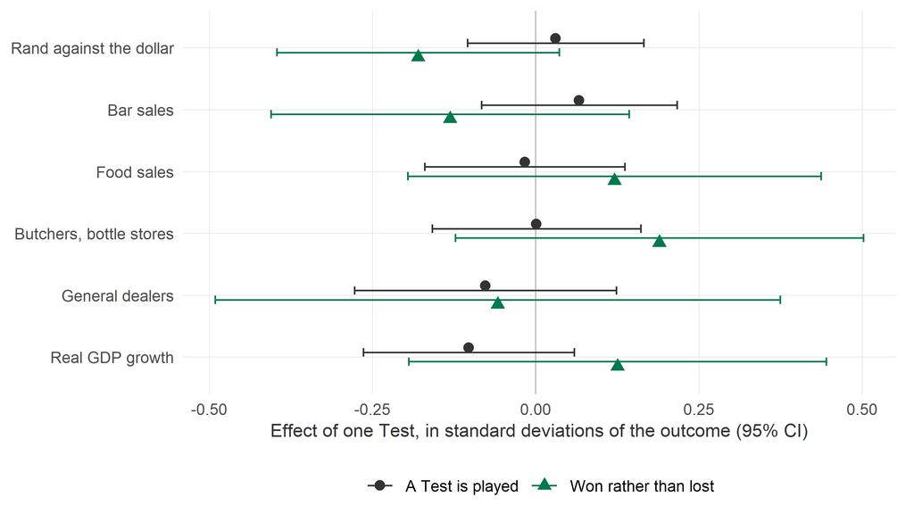

Figure 1: The two contrasts on each outcome, in standard deviations. Each estimate in Table 4 is divided by the standard deviation of what its regression leaves unexplained, which puts a weekend of the rand, a month of sales and a quarter of GDP on one axis. Bars are 95% confidence intervals. Sources: as for Table 4.

The percentages are not comparable across rows, because a weekend’s move in the rand and a month’s sales at a bottle store vary by very different amounts. Figure 1 divides each estimate by the standard deviation of what its regression leaves unexplained in an ordinary period. On that scale a Test is worth between −0.10 and 0.07 of a standard deviation, and winning between −0.18 and 0.19. The minimum detectable effects of a Test run from 0.19 to 0.29 of a standard deviation, so the six designs could each have seen an effect of a third of an ordinary period’s variation or less. The sections below take the timescales one at a time.

## 5.2 The weekend: the rand

Table 5: Weekend rand returns and Springbok Tests

|  | (1) | (2) | (3) | (4) |
| --- | --- | --- | --- | --- |
| A Test is played | 0.2 | 4.2 | 2.5 | 0.008 |
|  | (5.7) | (4.9) | (5.7) | (0.069) |
| Win | −2.7 | 0.4 | −2.2 | -0.029 |
|  | (7.0) | (6.0) | (6.7) | (0.079) |
| Loss | 7.7 | 13.2 | 12.6 | 0.096 |
|  | (8.3) | (7.2) | (8.0) | (0.104) |
| Win − Loss | −10.4 | −12.8 | −14.8 | -0.125 |
|  | (10.2) | (8.8) | (9.1) | (0.116) |
| Benchmark coefficient |  | 1.12 | 1.12 | 0.51 |
| Year and month effects | No | No | Yes | Yes |
| Weekends | 1,641 | 1,641 | 1,641 | 1,630 |
| R² | 0.000 | 0.280 | 0.297 | 0.151 |

*Notes:* OLS estimates over weekends. The first row is $\theta$ from Equation 1; the win, loss and win-minus-loss rows are from Equation 2, where a win and a loss are each measured against weekends without a Test. Columns (1) to (3) are in basis points of the rand’s Friday-to-Monday return against the dollar; positive means a stronger rand. Column (4) divides each weekend’s rand and benchmark returns by the standard deviation of the rand’s daily returns over the previous 60 fixes, so its coefficients are in standard deviations. HC3 standard errors in parentheses. The benchmark coefficient and R² are those of Equation 1. Draws are in Equation 2 and not reported.

Table 5 gives the rand’s results and Figure 2 shows the weekends behind them. Column (3) is the preferred specification. A weekend with a Test differs from other weekends by 2.5 basis points (95% CI −8.6 to 13.6; p = 0.656). Shuffling the Test indicator among the weekends of each month gives a randomisation p-value of 0.727 (Figure 3). The benchmark matters to the precision more than to the answer. In column (2) it explains 28% of the variation in weekend returns, with a coefficient of 1.12: on a typical weekend the rand moves a little more than the basket. Standardising returns by recent volatility, in column (4), changes nothing of substance.

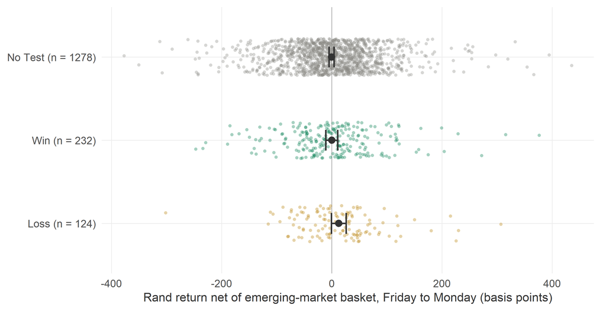

Figure 2: Weekend rand returns with and without a Springbok Test. Each dot is one weekend; the black point and bar are the group mean and its 95% confidence interval. Returns are net of the emerging-market basket, using the benchmark coefficient from column (3) of Table 5, with positive values meaning a stronger rand. Draws (n = 7) are omitted. Sources: World Rugby; Federal Reserve H.10 via FRED.

The minimum detectable effect is 15.9 basis points and the equivalence bound 11.8. The data rule out a Test moving the rand over the weekend by more than about 12 basis points in either direction, which at the latest fix of R17.48 per dollar is about 2.1 cents. For comparison, Edmans, García and Norli (2007) estimated rugby losses at −9.5 basis points on stock markets, and Geyer-Klingeberg *et al.* (2018) put the corrected loss effect for national football teams near −5. Effects of that size are smaller than this design can reliably detect, so a rugby effect on that scale may exist. A Springbok effect on the rand big enough to notice at the till has not shown up in 31 years.

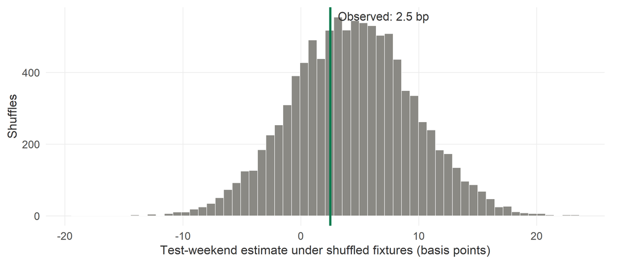

Figure 3: Randomisation inference for a Test being played. The histogram shows the estimate from 10,000 refits of column (3) of Table 5 with the Test indicator shuffled among weekends in the same month and year; the green line is the estimate from the real fixture list. Two-sided p-value: 0.727.

A Test could also move the rand without a direction, up after some matches and down after others, and $\theta$ would average that away. The size of the move would not. Net of the basket, the rand moves an average of 60 basis points in one direction or the other over a weekend without a Test. Regressing the size of each weekend’s move on the Test indicator, with the year and month effects of column (3), gives 0.4 basis points (95% CI −6.7 to 7.5; p = 0.911), so Test weekends move the rand no further than other weekends do.

The result adds nothing to the occasion. Measured against weekends without a Test, a win changes the weekend return by −2.2 basis points and a loss by 12.6, and the difference between them is −14.8 basis points (95% CI −32.6 to 2.9; p = 0.102). Shuffling results among the Tests of the same year gives 0.096. A win worth more than 2.9 basis points over a loss lies outside the interval, a limit that is tight because the estimate sits on the wrong side of zero; the symmetric equivalence bound, which does not lean on the sign, is 29.7 basis points. The point estimates have the rand slightly stronger after a loss than after a win, which is the wrong way round for the sentiment story. A loss-loving rand is not a finding this paper will defend, and the Springboks need not change their approach on its account. Section 5.3 shows where it comes from.

## 5.3 Checks on the rand

Figure 4 takes both contrasts through the days around the weekend, and Figure 5 through subsamples.

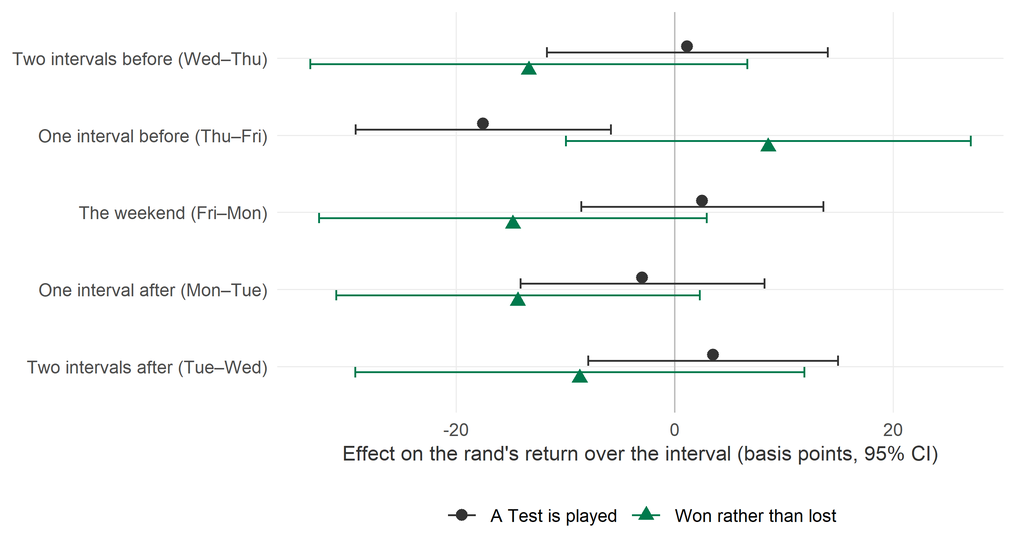

Figure 4: Both contrasts in the fix intervals around the weekend. Each point is the estimate from column (3) of Table 5 with the return over that interval as the dependent variable; bars are 95% confidence intervals from HC3 standard errors. The two intervals above the weekend close before kick-off. Sources: World Rugby; Federal Reserve H.10 via FRED.

**The day before.** The regression can be run on any fix interval, and Figure 4 runs it on the two before the weekend and the two after. Nothing a Test does can show in the intervals before it, and the fixture list is published months ahead, so there is no news in them either. Four of the five intervals show nothing for the Test indicator. The fifth is the one that closes before kick-off. On the Friday before a Test weekend the rand is 17.5 basis points weaker than on other Fridays (p = 0.003, or 0.033 after a Bonferroni adjustment for the ten estimates in Figure 4). Table 6 tries to make it go away. Winsorising the returns, replacing the month effects with an effect for each week of the year and comparing only weekends in the same month of the same year all leave it in place. It has the same sign in both halves of the sample, and before home Tests and away Tests alike (−21.4 and −14.4 basis points). The weekend does not undo it: from the Thursday fix to the Monday fix, Test weekends are −15.0 basis points against the rest (p = 0.069). This paper has no explanation for it.

Table 6: The interval before the weekend: Test weekends against other weekends (basis points)

| Check | Estimate | Std. error | p | Weekends |
| --- | --- | --- | --- | --- |
| Preferred specification | −17.5 | 6.0 | 0.003 | 1,641 |
| Winsorised at the 1% and 99% quantiles | −16.6 | 5.6 | 0.003 | 1,641 |
| Week-of-year effects in place of months | −17.4 | 6.3 | 0.006 | 1,641 |
| 1995–2009 | −14.1 | 10.2 | 0.167 | 767 |
| 2010–2026 | −19.4 | 7.1 | 0.006 | 874 |
| Within the same month and year | −22.8 | 9.3 | 0.014 | 588 |
| One interval earlier (Wed–Thu) | 1.1 | 6.6 | 0.861 | 1,641 |
| The weekend itself | 2.5 | 5.7 | 0.656 | 1,641 |

*Notes:* Each row is $\theta$ from Equation 1, the coefficient on the indicator for a weekend with a Springbok Test. Negative means a weaker rand around Test weekends. Except in the last two rows, the dependent variable is the return over the fix interval before the weekend, normally Thursday to Friday, with the basket’s return over the same interval as the benchmark. “One interval earlier” is the interval before that, normally Wednesday to Thursday. “Within the same month and year” replaces the year and month effects with one effect for each month of each year, and uses the weekends in months that had both a Test weekend and one without. HC3 standard errors.

For the design, it means that Test weekends differ from other weekends in some way the controls miss, which is the weakness of asking whether a Test was played: the answer is as good as the comparison. The Friday move is not part of the weekend estimate in Table 5, which starts from the Friday fix. Whatever sets those Fridays apart could be at work over the weekend too, though, so the weekend estimate for a Test being played rests on a comparison this placebo calls into question. The win-minus-loss contrast is on firmer ground, since it compares Test weekends with each other. On the Friday before, it is 8.6 basis points (p = 0.366).

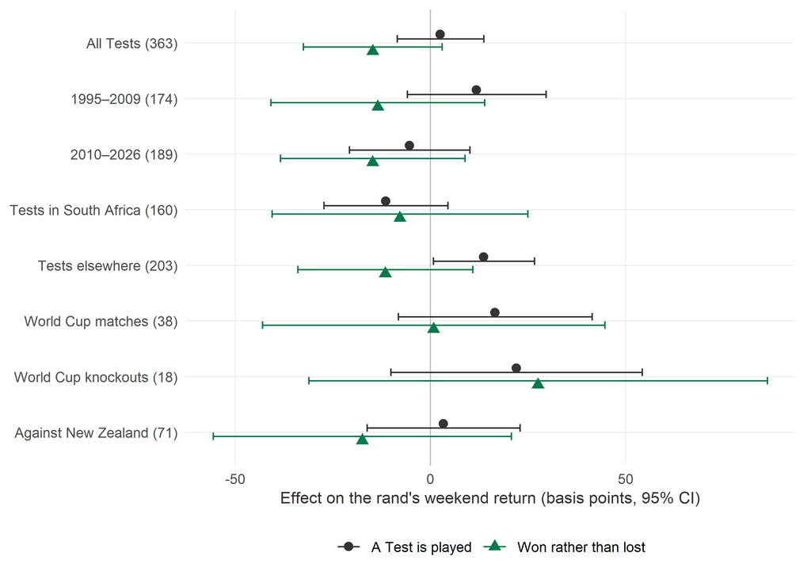

Figure 5: Both contrasts across samples. Points are estimates from column (3) of Table 5 for the Tests in each sample, with all weekends without a Test as the comparison; bars are 95% confidence intervals from HC3 standard errors. Counts are Test weekends. Sources: World Rugby; Federal Reserve H.10 via FRED.

**Home and away.** Splitting the Test weekends by venue gives −11.5 basis points for Tests in South Africa and 13.7 for Tests elsewhere (p = 0.157 and p = 0.038), a gap of 25.1 basis points (p = 0.007). A Test’s venue is settled long before the weekend, so this is no more a reaction to rugby than the Friday is. Much of it is the calendar. 39% of the home Tests were played in June and 39% of the away Tests in November, so the two are measured against different weekends without a Test. With an effect for each week of the year in place of the month effects, the gap narrows to 18.7 basis points (p = 0.051), and the estimate for all Tests is 6.6 (p = 0.254). It is one split among the 5 in Figure 5 and is read here as exploratory.

**The result.** Figure 4 also follows the win-minus-loss contrast. A difference of much the same size as the weekend’s appears two intervals before the match (−13.4 basis points), where the result cannot have caused it, and again in the interval after the weekend (−14.4). That fits a difference in when and where the Springboks lose better than it fits a reaction to the result. With an indicator for Tests played outside South Africa, the weekend contrast falls to −9.9 basis points (p = 0.292). Adding opponent effects takes it to −7.1 (p = 0.508); the 9 opponents with 10 or more weekend Tests get an effect each and the rest share one.

**Bigger matches.** If a Test moved the rand, it should show most at the matches people care about most. The estimate for World Cup matches is 16.6 basis points and for World Cup knockouts 22.1, with confidence intervals 50 and 64 basis points wide that both include zero. Winning them rather than losing is worth 0.8 and 27.5 basis points, the Springboks having lost only 4 World Cup knockout matches on a weekend in the sample. Against New Zealand, where the Springbok record since March 1995 is 26 wins, 46 losses and 1 draw, a Test is worth 3.3 basis points and a win over a loss −17.5.

**Margin.** Adding the points margin to the Test indicator gives −0.15 basis points per point (95% CI −0.62 to 0.31). The margins run from a 57-point loss to New Zealand in 2017 to a 131-point win over Uruguay in 2005, and the rand took no visible interest in either end.

**Weekday Tests.** The 21 Tests played on weekdays, 12 of them at World Cups, are measured from the last fix before the match date to the first fix after it, which brackets the match whatever its kick-off time. The rand’s return net of the benchmark averaged −6.2 basis points across them, with a standard deviation of 108.

## 5.4 The month: braai economics

The braai hypothesis is about the occasion. Brandy and braai meat are bought ahead of the game and bars fill during it, whoever wins. If that spending is new, the month that holds the Test should show it.

Table 7: Monthly real sales and Springbok Tests, January 2008 to September 2026

| Series | Per Test | 95% CI | MDE | MDE, R million | June 2010 | Months |
| --- | --- | --- | --- | --- | --- | --- |
| Bar sales | 0.34 (0.39) | −0.42 to 1.10 | 1.08 | 8 | 16.3 (5.6) | 202 |
| Food sales | −0.04 (0.17) | −0.38 to 0.30 | 0.48 | 30 | 10.1 (2.4) | 202 |
| All F&B income | 0.03 (0.16) | −0.29 to 0.34 | 0.45 | 32 | 11.1 (2.6) | 202 |
| Specialised stores | 0.00 (0.22) | −0.43 to 0.44 | 0.63 | 53 | 3.9 (3.0) | 203 |
| General dealers | −0.22 (0.29) | −0.78 to 0.35 | 0.81 | 364 | 4.3 (3.1) | 203 |

*Notes:* OLS estimates of Equation 1 on monthly data. Coefficients are 100 times the change in the log of the month’s real sales, which reads as percent for small values; the June 2010 coefficient for bar sales, 16.3, is a rise of 17.7%. Standard errors are in parentheses: Newey–West for the per-Test effect, classical for June 2010, which is an indicator for a single month. Bar and food sales are income from bar and food sales in restaurants and coffee shops, takeaway and fast-food outlets, and caterers; “All F&B income” is that industry’s total income. “Specialised stores” are retailers of food, beverages and tobacco in specialised stores (butchers and bottle stores among them). “Per Test” is the effect of one more Springbok Test in the month. MDE is the minimum detectable effect at 5% significance and 80% power, in percent and in R million at the series’ average monthly sales over its last 12 months, at constant prices. “June 2010” is the football World Cup month, the positive control. Months from March 2020 to December 2021 are excluded. Sources: Stats SA P6420 and P6242.1; World Rugby.

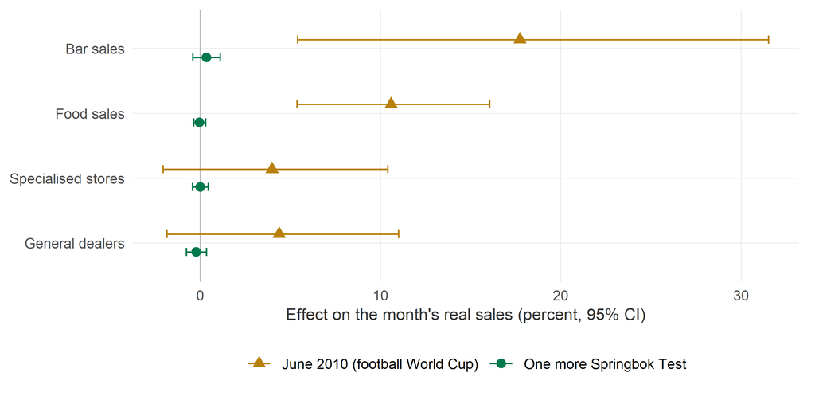

Figure 6: One more Springbok Test in a month beside the 2010 football World Cup. Points are estimates from Equation 1 of the effect on the month’s real sales, converted from log points to percent; bars are 95% confidence intervals, from Newey–West standard errors for a Test and classical ones for June 2010. Sources: Stats SA P6420 and P6242.1; World Rugby.

Table 7 and Figure 6 give the results. One more Springbok Test in a month changes real bar sales by 0.34% (95% CI −0.42 to 1.10). The equivalence bound is 0.97%, so the data rule out a Test adding more than that to a month’s bar sales, which is 0.30 of an average day’s takings. Food sales in the same outlets, sales at specialised food, drink and tobacco stores and sales at general dealers all move by less than half a percent either way per Test. At the specialised stores, the butchers and bottle stores, the estimate is 0.00%, with an equivalence bound of 0.37%. Ending the sample in March 2024 gives 0.41% for bar sales.

In rand the series are not equally sharp. The specialised stores sell about R8.5 billion a month, so their interval runs from −R37 million to R38 million per Test, and the design could reliably detect about R53 million. General dealers sell about R45 billion a month, and there the smallest effect the design could detect is R364 million per Test. Braai meat and brandy bought with the weekly shop at a supermarket land in that series, where an effect of tens of millions of rand would pass unseen.

Bar and food sales can see an event. In June 2010 real bar sales were 18% higher than the calendar and the year predict (p = 0.004) and food sales 11% (p < 0.001). With nothing in the model to mark it, June 2010 ranks 2nd of the 202 months by the size of its studentised residual in bar sales, and 1st in food sales. That tournament brought an estimated 220,000 extra arrivals from outside the Southern African Development Community (Peeters, Matheson and Szymanski, 2014): money from outside the economy.

The two retail series are a weaker control. Sales at specialised stores were 4% higher that June and at general dealers 4%, and neither can be told from an ordinary month (p = 0.200 and p = 0.171; 33rd and 52nd of 203 months). General dealers did sell 9% more in July 2010 (p = 0.005); the specialised stores show nothing in either month. For butchers and bottle stores the positive control did not work, so the null there rests on the minimum detectable effect in Table 7.

The calendar does show up at those stores. A fifth Saturday in a month adds 2.0% to sales at specialised stores and 1.5% to all food and beverage income, in both cases significantly more than an extra Test does (p < 0.001 and p = 0.002). For bar sales the estimate is 2.1%, and its gap of 1.7 log points over an extra Test is not significant (p = 0.118). The month with Good Friday in it adds 2.6% to bar sales.

Table 8: Splits of the monthly spending estimates (percent of the month’s real sales)

| Series | Win | Loss | Home | Away | Knockout | Next month |
| --- | --- | --- | --- | --- | --- | --- |
| Bar sales | 0.20 (0.47) | 0.86 (0.51) | −0.13 (0.55) | 0.62 (0.47) | 1.02 (1.03) | 0.55 (0.42) |
| Food sales | 0.02 (0.16) | −0.25 (0.37) | 0.12 (0.26) | −0.13 (0.19) | −0.85 (0.48) | 0.19 (0.17) |
| All F&B income | 0.06 (0.16) | −0.09 (0.38) | 0.01 (0.29) | 0.04 (0.15) | −0.63 (0.43) | 0.38 (0.15) |
| Specialised stores | 0.11 (0.23) | −0.41 (0.41) | 0.21 (0.27) | −0.12 (0.27) | 1.09 (0.55) | −0.15 (0.18) |
| General dealers | −0.25 (0.34) | −0.08 (0.51) | −0.48 (0.17) | −0.06 (0.43) | −0.14 (0.67) | 0.06 (0.20) |

*Notes:* Estimates from variants of Equation 1 on monthly data, per match, Newey–West standard errors in parentheses. “Win” and “Loss” are $\theta_W$ and $\theta_L$ from Equation 2; “Home” and “Away” split the Test count by venue in the same way. “Knockout” is the additional effect of a World Cup knockout match over an ordinary Test. “Next month” is the placebo: the number of Tests in the following month, which cannot have caused this month’s sales. Sources: Stats SA P6420 and P6242.1; World Rugby.

The result does not matter here either. Per win, bar sales change by 0.20% and per loss by 0.86%. The win-minus-loss difference of −0.66 points (p = 0.349) leans the way Business Insider SA predicted, and at the specialised stores it leans the other way (0.52 points, p = 0.235). Across the 25 exploratory estimates in the win, loss, home, away and knockout columns of Table 8, 2 have p-values below 0.05, about what chance alone would give (1.2 expected), and none survives Holm’s adjustment.

The placebo is less clean. Next month’s Tests cannot have caused this month’s sales, yet a Test next month goes with 0.38% more food and beverage income this month (p = 0.012, or 0.062 after Holm’s adjustment across the five series). For bar sales the placebo estimate of 0.55% is larger than the 0.34% it is a placebo for. Year and month effects do not capture the season perfectly, and what they miss is about the size of the per-Test estimates. That is a further reason to read those estimates as noise around zero.

The card data and the monthly totals are consistent with each other. The spike around a big match is real, and it does not show up in the month’s sales. Either it is short, or it is paid for by other days, or both. For drinks at restaurants, takeaways and caterers, and at butchers and bottle stores, a Test month is an ordinary month. Pubs and taverns are not among the food and beverages survey’s types of business, and the surveys cover the businesses in Stats SA’s samples, so spending at pubs, at informal taverns and shebeens, and by fans abroad may not be captured.

## 5.5 The quarter: output

Table 9: Quarterly real GDP growth and Springbok Tests (percentage points of growth)

| Contrast | Estimate | Std. error | 95% CI | p | Quarters |
| --- | --- | --- | --- | --- | --- |
| One more Test | −0.062 | 0.049 | −0.159 to 0.035 | 0.213 | 130 |
| One more win | −0.050 | 0.039 | −0.126 to 0.026 | 0.197 | 130 |
| One more loss | −0.125 | 0.128 | −0.376 to 0.126 | 0.329 | 130 |
| Win minus loss | 0.075 | 0.098 | −0.117 to 0.267 | 0.443 | 130 |
| Placebo: one more Test next quarter | −0.010 | 0.027 | −0.063 to 0.044 | 0.724 | 129 |
| One more Test, with 2020Q2 and 2020Q3 | −0.245 | 0.249 | −0.732 to 0.243 | 0.326 | 132 |

*Notes:* OLS estimates of Equation 1 and Equation 2 on quarterly data, with year and quarter-of-year effects and Newey–West standard errors. The dependent variable is quarter-on-quarter growth of seasonally adjusted real GDP in percent. All rows but the last leave out 2020Q2 and 2020Q3. Sources: IMF International Financial Statistics via FRED; World Rugby.

One more Test in a quarter goes with −0.06 percentage points of growth (95% CI −0.16 to 0.04; p = 0.213). The placebo is clean: next quarter’s Tests go with −0.010 points (p = 0.724). Winning rather than losing is worth 0.08 points (−0.12 to 0.27). With the two 2020 quarters left in, the standard error is 5 times as large and the estimate says nothing.

The minimum detectable effect is 0.14 percentage points of a quarter’s growth per Test. Against the latest quarter’s nominal GDP of R2.01 trillion, that is about R2.8 billion. The quarter is a blunt instrument for a braai. It could see a Test that moved the whole economy and nothing as small as what the monthly sales leave room for.

## 5.6 The four titles

The usual evidence for a Springbok effect is not an average over Tests. It is four weeks, the ones after the World Cup finals of 1995, 2007, 2019 and 2023, and Table 10 shows the rand and the basket after each, to the Monday fix and over the following week.

Table 10: The rand after the four World Cup finals won (percent)

| Year | Result | Rand, Mon | Basket, Mon | Net, Mon | Rand, week | Basket, week | Net, week |
| --- | --- | --- | --- | --- | --- | --- | --- |
| 1995 | 15–12 v New Zealand | 0.11 | 0.01 | 0.10 | 0.14 | -0.02 | 0.16 |
| 2007 | 15–6 v England | -0.62 | -0.40 | -0.17 | 4.66 | 0.42 | 4.19 |
| 2019 | 32–12 v England | 1.91 | -0.12 | 2.04 | 1.59 | -1.04 | 2.76 |
| 2023 | 12–11 v New Zealand | 0.11 | -0.11 | 0.23 | 3.11 | 1.93 | 0.95 |

*Notes:* Log changes in percent from the Friday noon fix before the final, positive meaning a stronger currency against the dollar. “Mon” runs to the Monday fix after the final and “week” to the following Friday. “Net” is the rand’s change less the benchmark coefficient (1.12) times the basket’s change. Sources: World Rugby; Federal Reserve H.10 via FRED.

Two of the four weeks fit the story told about them, and both had other news. In 2007 the rand gained 4.7% over the week against 0.4% for the basket. That is a little more than the blog post’s 4.3%, which may have used different fixes. The weekend itself contributed nothing: at Monday’s fix the rand was 0.6% weaker than on the Friday before the final. By Wednesday’s fix it was 2.0% stronger than on that Friday, and it added another 2.6 points by the end of the week. Standard Bank had issued a cautionary announcement on the Tuesday that talks were under way, and the ICBC offer for a fifth of the bank was announced on the Thursday (Allen, 2007). The Sowetan reported the next morning that “news of the deal saw the rand strengthen to R6,55 to the dollar yesterday” (Laing, 2007). That accounts for the end of the week. Whether the cautionary moved the rand on the Tuesday and Wednesday, these sources do not say.

In 2019 the rand gained 1.9% from Friday to Monday while the basket lost 0.1%. On the Friday, Moody’s had affirmed South Africa’s Baa3 rating, one notch above non-investment grade, and changed its outlook to negative (National Treasury, 2019). An analyst quoted by BusinessTech put the decision “late on Friday evening” (BusinessTech, 2019). Noon in New York that day was 18:00 in Johannesburg, so the Monday fix was the first to price it. Reuters reported on the Monday that the rand and government bonds had jumped after the decision, which a small minority of investors had expected to be a downgrade or a move to “on watch” (Reuters, 2019). It gave two other supports for the rally: appetite for high-yielding emerging-market assets, and the sell-off of the week before, when the medium-term budget brought what it called the rand’s largest daily fall in over a year. The fixes show that sell-off. The rand lost 3.0% over the three fixes to that Friday’s, 2.6% of it on the Wednesday of the budget, and after Monday’s gain it was still 1.1% below where it stood before the budget. BusinessTech’s report that morning led with progress in trade talks between the United States and China alongside the rating, and quoted the same analyst as saying most investors felt the decision had been priced in (BusinessTech, 2019). The basket did not rise with the rand, which favours the news that was specific to South Africa.

After the 1995 and 2023 finals the rand moved by at most 0.23% net of the basket to the Monday. Four weeks with known confounders cannot separate rugby from banking deals and credit ratings. The weekend regressions in Table 5 average over hundreds of Tests, and they find nothing.

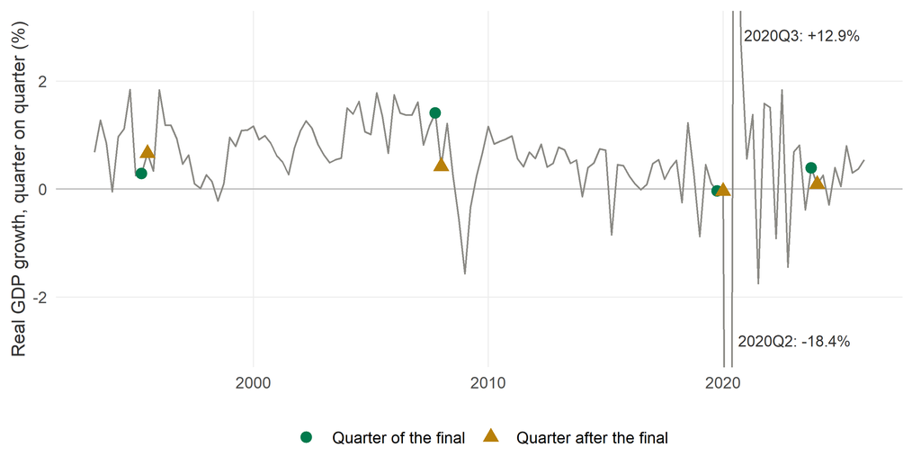

Figure 7: Quarterly real GDP growth, with the quarters that held a World Cup final and the quarters after them marked. The vertical axis is cut at ±3%; quarters beyond it are labelled. Source: IMF International Financial Statistics via FRED (series NGDPRSAXDCZAQ).

Table 11: Quarterly real GDP growth in World Cup quarters

| Treated | Sample | Quarters | Difference (pp) | p | MDE (pp) |
| --- | --- | --- | --- | --- | --- |
| Quarter of the final | All quarters | 132 | -0.05 | 0.896 | 2.98 |
| Quarter after the final | All quarters | 132 | -0.29 | 0.439 | 2.98 |
| Quarter of the final | Without 2020Q2 and 2020Q3 | 130 | -0.10 | 0.759 | 0.97 |
| Quarter after the final | Without 2020Q2 and 2020Q3 | 130 | -0.34 | 0.325 | 0.97 |

*Notes:* Difference between mean quarter-on-quarter growth in the four treated quarters and in the rest, in percentage points. p-values from 10,000 random draws of four quarters. MDE is the minimum detectable difference at 5% significance and 80% power. Source: IMF International Financial Statistics via FRED.

The titles do not show in output either (Figure 7 and Table 11). Growth in the quarters of the four finals was 0.05 percentage points below the average for other quarters (p = 0.896), and in the quarters after them 0.29 points below (p = 0.439). The quarter of the 2019 final and the one after it both shrank slightly; the quarters around the other three finals all grew. Three of the finals were played in October or November, with 59 to 72 days of the quarter still to run. The 1995 final was played 6 days before the end of its quarter, in a tournament South Africa hosted, so for 1995 the quarter of the final measures hosting and the quarter after it is the first under a title. With four titles the comparison is weak. Even without the two 2020 quarters, a title would have needed to add about 1.0 percentage points to a quarter’s growth to be reliably detected, 1.6 times the average quarter’s growth over the sample.

## 5.7 A regression to ignore

Regressing the logarithm of the rand’s annual average exchange rate on the number of World Cups won to date, 1995 to 2025, gives a coefficient of 0.392 (t = 8.1, R² = 0.69). Taken at face value, each title has raised the rand price of a dollar by 48%, which is 32% off what a rand buys, and Figure 8 shows how well the step function fits.

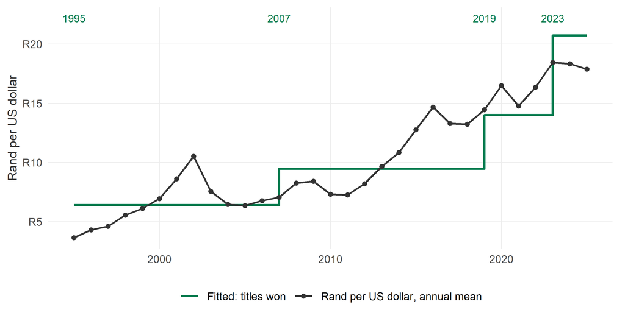

Figure 8: The rand and the World Cup model. The black line is the rand’s annual mean exchange rate against the dollar (higher means weaker); the green step is the fitted value from regressing its logarithm on the number of World Cups won to date. Years of titles are marked at the top. Sources: Federal Reserve H.10 via FRED; World Rugby.

Both series trend upwards over the period. The rand weakened for reasons that include inflation differentials, commodity prices and domestic policy, and the title count can only rise. Regressing one trending series on another produces large t-statistics whether or not the two are related, as Granger and Newbold (1974) showed with random walks. In annual changes the relationship disappears: the coefficient is 0.033 with a standard error of 0.077, and R² falls to 0.007. There is no evidence that the Springboks have cost the rand anything.

# 6 The holiday

The 2023 public holiday is the one economic consequence of a Springbok Test that is not in doubt. Two days after the 2023 final, the President announced that 15 December 2023 would be a public holiday (Ramaphosa, 2023). It was proclaimed under section 2A of the Public Holidays Act, which lets the President declare any day a public holiday by proclamation in the Gazette (Republic of South Africa, 1995; The Presidency, 2023). The economist Dawie Roodt estimated that “the loss to production for the economy would be between R10 to R20 billion per day” (Maluleke, 2023). Against nominal GDP of R1.80 trillion in 2023Q4, that is 0.56% to 1.11% of the quarter’s output. Real GDP grew 0.39% that quarter. The quarterly figures cannot separate one day’s holiday from everything else that happened in it.

# 7 Discussion

The three timescales agree, and the power calculations say how much that agreement is worth. Over a weekend the design rules out a Test moving the rand by more than about 12 basis points. Over a month it could reliably detect about 1.1% of bar sales and 0.6% of sales at butchers and bottle stores. Over a quarter it could detect 0.14 percentage points of growth. Smaller effects may exist. In rand the three are far apart: about R8 million per Test in bar sales at restaurants, takeaways and caterers, R53 million at the specialised stores, R364 million at general dealers and R2.8 billion of GDP. A braai effect worth tens of millions of rand per Test is something only the first two could have seen.

Several limits remain. Asking whether a Test was played means comparing Test periods with other periods, and fixtures are not drawn at random. The season and year effects, the week-of-year check and the placebos are the defence, and one placebo failed: the rand was weaker on the Friday before a Test than on other Fridays, and the paper cannot say why. The design treats a surprise loss and an expected one alike; pre-match odds would sharpen the test of the result, and would separate it from where and against whom it came. Daily fixes cannot see a move at the Monday open that reverses before noon in New York, which is the intraday channel Ehrmann and Jansen (2016) found in stock prices. The rand is set in a global market where South African sentiment is one input among many. The monthly data cannot see a spike that is paid for within the same month, which is the point, and they miss pubs, taverns and the informal sector. Attendance at work on the Monday and the national mood are untested. Kavetsos and Szymanski (2010) found no happiness effect of national sporting success; the search for this paper found no such test for South Africa.

# 8 Conclusion

When the Springboks play, nothing in the economy measurably moves. Over 31 years the rand’s weekend return is the same with a Test as without one, to within about 12 basis points, and the rand moves no further in either direction. A month with one more Test sells no more drink at restaurants, takeaways and caterers, and no more at butchers or bottle stores, than the same month in another year, and a quarter with more Tests grows no faster. Winning rather than losing changes none of that. The one sporting month that shows up in restaurant, takeaway and catering sales is the one that brought foreign visitors. The rallies that followed two World Cup finals coincided with a record foreign investment and a reprieve from Moody’s, and the regression that blames the titles for the rand’s decline is an artefact of two trending series. What the paper cannot explain is a weaker rand on the Friday before a Test.

The policy recommendations are that the South African Reserve Bank need not add Springbok fixtures to its calendar, and that a butcher or bottle store hoping for a good month should want five Saturdays in it more than a Test match. The Reserve Bank’s MPC may well watch the rugby anyway.

# References

Allen, J. (2007) *South Africa: Chinese to invest R36.7 billion in local bank*. allAfrica. Available at: https://allafrica.com/stories/200710250782.html (Accessed: November 25, 2026).

Ashton, J.K., Gerrard, B. and Hudson, R. (2003) “Economic impact of national sporting success: Evidence from the London stock exchange,” *Applied Economics Letters*, 10(12), pp. 783–785. Available at: https://doi.org/10.1080/1350485032000126712.

Ashton, J.K., Gerrard, B. and Hudson, R. (2011) “Do national soccer results really impact on the stock market?” *Applied Economics*, 43(26), pp. 3709–3717. Available at: https://doi.org/10.1080/00036841003689762.

Baade, R.A., Baumann, R. and Matheson, V.A. (2008) “Selling the game: Estimating the economic impact of professional sports through taxable sales,” *Southern Economic Journal*, 74(3), pp. 794–810. Available at: https://doi.org/10.1002/j.2325-8012.2008.tb00864.x.

Baade, R.A. and Matheson, V.A. (2004) “The quest for the cup: Assessing the economic impact of the World Cup,” *Regional Studies*, 38(4), pp. 343–354. Available at: https://doi.org/10.1080/03434002000213888.

Bank of Ireland (2023) *Social spending falls in September despite Irish Rugby World Cup victories*. Available at: https://www.bankofireland.com/about-bank-of-ireland/press-releases/2023/social-spending-falls-in-september-despite-irish-rugby-world-cup-victories/ (Accessed: November 25, 2026).

Board of Governors of the Federal Reserve System (2026) *H.10 Foreign Exchange Rates: Noon buying rates in New York (DEXSFUS, DEXBZUS, DEXMXUS, DEXINUS, DEXKOUS, DEXTHUS)*. Retrieved from FRED, Federal Reserve Bank of St. Louis. Available at: https://fred.stlouisfed.org/series/DEXSFUS (Accessed: November 25, 2026).

Botha, F. and De Beer, C. (2013) “Does national sporting performance affect stock market returns in South Africa?” *Journal of Economic and Financial Sciences*, 6(1), pp. 67–82. Available at: https://doi.org/10.4102/jef.v6i1.277.

Boyle, G. and Walter, B. (2003) “Reflected glory and failure: International sporting success and the stock market,” *Applied Financial Economics*, 13(3), pp. 225–235. Available at: https://doi.org/10.1080/09603100210148230.

BusinessTech (2019) *Rand surges after Moody’s boost*. Available at: https://businesstech.co.za/news/business/350889/rand-surges-after-moodys-boost/ (Accessed: November 25, 2026).

Coates, D. and Depken, C.A. (2011) “Mega-events: Is Baylor football to Waco what the Super Bowl is to Houston?” *Journal of Sports Economics*, 12(6), pp. 599–620. Available at: https://doi.org/10.1177/1527002510391368.

Coates, D. and Humphreys, B.R. (2003) “The effect of professional sports on earnings and employment in the services and retail sectors in US cities,” *Regional Science and Urban Economics*, 33(2), pp. 175–198. Available at: https://doi.org/10.1016/s0166-0462(02)00010-8.

de Villiers, J. (2019) *SA liquor outlets should want the Springboks to lose. Here’s why*. Business Insider SA, reposted by the University of Pretoria Department of Psychology. Available at: https://www.up.ac.za/psychology/news/sa-liquor-outlets-should-want-springboks-lose-heres-why (Accessed: November 25, 2026).

Demir, E., Lau, C.K.M. and Fung, K.W.T. (2014) “The effect of international soccer games on exchange rates using evidence from Turkey,” *Journal of Advanced Studies in Finance*, 5(2), pp. 145–156. Available at: https://ideas.repec.org/a/srs/jasf00/v5y2014i2p145-156.html.

Discovery Bank (2023) *Discovery Bank SpendTrend Rugby World Cup 2023 edition*. Available at: https://www.discovery.co.za/bank/news-rugby-spend-trend (Accessed: November 25, 2026).

Edmans, A., García, D. and Norli, Ø. (2007) “Sports sentiment and stock returns,” *The Journal of Finance*, 62(4), pp. 1967–1998. Available at: https://doi.org/10.1111/j.1540-6261.2007.01262.x.

Ehrmann, M. and Jansen, D.-J. (2016) “It hurts (stock prices) when your team is about to lose a soccer match,” *Review of Finance*, 20(3), pp. 1215–1233. Available at: https://doi.org/10.1093/rof/rfv031.

Eker, G., Berument, H. and Dogan, B. (2007) “Football and exchange rates: Empirical support for behavioral economics,” *Psychological Reports*, 101(2), pp. 643–654. Available at: https://doi.org/10.2466/pr0.101.2.643-654.

Gerlach, J.R. (2011) “International sports and investor sentiment: Do national team matches really affect stock market returns?” *Applied Financial Economics*, 21(12), pp. 863–880. Available at: https://doi.org/10.1080/09603107.2010.543069.

Geyer-Klingeberg, J. *et al.* (2018) “Do stock markets react to soccer games? A meta-regression analysis,” *Applied Economics*, 50(19), pp. 2171–2189. Available at: https://doi.org/10.1080/00036846.2017.1392002.

Granger, C.W.J. and Newbold, P. (1974) “Spurious regressions in econometrics,” *Journal of Econometrics*, 2(2), pp. 111–120. Available at: https://doi.org/10.1016/0304-4076(74)90034-7.

Holm, S. (1979) “A simple sequentially rejective multiple test procedure,” *Scandinavian Journal of Statistics*, 6(2), pp. 65–70. Available at: https://www.jstor.org/stable/4615733.

Inside Education (2023) *NWU academic speaks on the economic impact of the Rugby World Cup*. Available at: https://insideeducation.co.za/nwu-academic-speaks-on-the-economic-impact-of-the-rugby-world-cup/ (Accessed: November 25, 2026).

International Monetary Fund (2026) *Real and nominal gross domestic product for South Africa, seasonally adjusted (NGDPRSAXDCZAQ, NGDPSAXDCZAQ), International Financial Statistics*. Retrieved from FRED, Federal Reserve Bank of St. Louis. Available at: https://fred.stlouisfed.org/series/NGDPRSAXDCZAQ (Accessed: November 25, 2026).

Kaplanski, G. and Levy, H. (2010) “Exploitable predictable irrationality: The FIFA World Cup effect on the U.S. stock market,” *Journal of Financial and Quantitative Analysis*, 45(2), pp. 535–553. Available at: https://doi.org/10.1017/S0022109010000153.

Kavetsos, G. and Szymanski, S. (2010) “National well-being and international sports events,” *Journal of Economic Psychology*, 31(2), pp. 158–171. Available at: https://doi.org/10.1016/j.joep.2009.11.005.

Klein, C., Zwergel, B. and Fock, J.H. (2009) “Reconsidering the impact of national soccer results on the FTSE 100,” *Applied Economics*, 41(25), pp. 3287–3294. Available at: https://doi.org/10.1080/00036840802112471.

Laing, R. (2007) *Standard Bank deal sets record for foreign direct investment into South Africa*. Sowetan. Available at: https://www.sowetan.co.za/news/2007-10-26-standard-bank-deal-sets-record-for-foreign-direct-investment-into-south-africa/ (Accessed: November 25, 2026).

Lakens, D. (2017) “Equivalence tests: A practical primer for *t* tests, correlations, and meta-analyses,” *Social Psychological and Personality Science*, 8(4), pp. 355–362. Available at: https://doi.org/10.1177/1948550617697177.

Liebenberg, C.F. (1995) *Statement issued by Mr C.F. Liebenberg, Minister of Finance, on the abolition of the financial rand system, 10 March 1995*. South African Reserve Bank, Quarterly Bulletin No. 196, June 1995, p. 25. Available at: https://www.resbank.co.za/content/dam/sarb/publications/quarterly-bulletins/quarterly-bulletin-publications/1995/5175/03Statement-issued-by-Mr-C.F.-Liebenberg%2D%2DMinister-of-Finance%2D%2Don-the-abolition-of-the-financial-rand-system.pdf (Accessed: November 25, 2026).

MacKinlay, A.C. (1997) “Event studies in economics and finance,” *Journal of Economic Literature*, 35(1), pp. 13–39. Available at: https://ideas.repec.org/a/aea/jeclit/v35y1997i1p13-39.html.

MacKinnon, J.G. and White, H. (1985) “Some heteroskedasticity-consistent covariance matrix estimators with improved finite sample properties,” *Journal of Econometrics*, 29(3), pp. 305–325. Available at: https://doi.org/10.1016/0304-4076(85)90158-7.

Maluleke, V. (2023) *Boks’ World Cup victory: Ramaphosa’s public holiday gets thumbs-down from economists*. The Citizen. Available at: https://www.citizen.co.za/business/ramaphosa-boks-public-holiday-thumbs-down-economists/ (Accessed: November 25, 2026).

Moultrie, T.A. *et al.* (2021) “Unnatural deaths, alcohol bans and curfews: Evidence from a quasi-natural experiment during COVID-19,” *South African Medical Journal*, 111(9), pp. 834–837. Available at: https://doi.org/10.7196/samj.2021.v111i9.15813.

National Treasury (2019) *Treasury on rating action of Moody’s Investors Service*. South African Government. Available at: https://www.gov.za/news/media-statements/treasury-rating-action-moody%E2%80%99s-investors-service-01-nov-2019 (Accessed: November 25, 2026).

Neal, D.J. and Fromme, K. (2007) “Hook ’em horns and heavy drinking: Alcohol use and collegiate sports,” *Addictive Behaviors*, 32(11), pp. 2681–2693. Available at: https://doi.org/10.1016/j.addbeh.2007.06.020.

Newey, W.K. and West, K.D. (1987) “A simple, positive semi-definite, heteroskedasticity and autocorrelation consistent covariance matrix,” *Econometrica*, 55(3), pp. 703–708. Available at: https://doi.org/10.2307/1913610.

Peeters, T., Matheson, V. and Szymanski, S. (2014) “Tourism and the 2010 World Cup: Lessons for developing countries,” *Journal of African Economies*, 23(2), pp. 290–320. Available at: https://doi.org/10.1093/jae/ejt031.

R Core Team (2025) *R: A language and environment for statistical computing*. Vienna, Austria: R Foundation for Statistical Computing. Available at: https://www.R-project.org/.

Ramaphosa, C. (2023) *President Cyril Ramaphosa: Progress of economic recovery*. South African Government. Available at: https://www.gov.za/news/speeches/president-cyril-ramaphosa-progress-economic-recovery-30-oct-2023 (Accessed: November 25, 2026).

Republic of South Africa (1995) *Public Holidays Amendment Act 48 of 1995*. Available at: https://www.gov.za/sites/default/files/gcis_document/201409/act48of1995.pdf (Accessed: November 25, 2026).

Republic of South Africa (2010) *Standard industrial classification codes per SETA, Government Gazette no. 33756*. copy hosted by AgriSETA. Available at: https://www.agriseta.co.za/wp-content/uploads/2021/02/ALL_SIC_CODES_PER_SETA.pdf (Accessed: November 25, 2026).

Reuters (2019) *South Africa rand and bonds bounce on Moody’s ratings reprieve*. Business Recorder. Available at: https://www.brecorder.com/news/amp/541336 (Accessed: November 25, 2026).

Smith, B.K. and Krige, J.D. (2010) “Evaluating the economic impact of national sporting performance: Evidence from the Johannesburg Stock Exchange,” *South African Journal of Business Management*, 41(3), pp. 1–11. Available at: https://doi.org/10.4102/sajbm.v41i3.520.

Standard Bank (2015) *Can a win on the field relate to a win on the markets?* Standard Bank Community blog (archived copy). Available at: http://web.archive.org/web/20210727055516/https://community.standardbank.co.za/t5/Community-blog/Can-a-win-on-the-field-relate-to-a-win-on-the-markets/ba-p/3814 (Accessed: November 25, 2026).

Statistics South Africa (2026a) *Food and beverages (P6420), time series to August 2026*. Available at: https://www.statssa.gov.za/timeseriesdata/Excel/P6420%20Food%20and%20beverages%20(202608).zip (Accessed: November 25, 2026).

Statistics South Africa (2026b) *Retail trade sales (P6242.1), new time series from January 2002, to September 2026*. Available at: https://www.statssa.gov.za/timeseriesdata/Excel/P6242.1%20Retail%20trade%20sales%20(New%20time%20series)%20from%20January%202002_202609.zip (Accessed: November 25, 2026).

The Presidency (2023) *Proclamation No. 143 of 2023: Declaration of 15 December 2023 as a public holiday, Government Gazette No. 49773*. Available at: https://www.gov.za/sites/default/files/gcis_document/202311/49773pr143.pdf (Accessed: November 25, 2026).

Tobias, C. (2026) “rugby-tournament-predictor: International results database, compiled mostly from the ESPN scoreboard and a historical import, with some Tests from World Rugby (unpublished).”

Williamson, N. (2025) *Springboks stunner: Wallabies produce all-time comeback to dethrone world champions Springboks*. rugby.com.au. Available at: https://www.rugby.com.au/news/springboks-stunner-wallabies-produce-alltime-comeback-to-dethrone-world-champions-springboks-2025816 (Accessed: November 25, 2026).

World Rugby (2026) *Match list, men’s fifteens, South Africa (team 39), 1992–2026*. Available at: https://api.wr-rims-prod.pulselive.com/rugby/v3/match?sport=mru&teams=39 (Accessed: November 25, 2026).

Young, A. (2019) “Channeling Fisher: Randomization tests and the statistical insignificance of seemingly significant experimental results,” *The Quarterly Journal of Economics*, 134(2), pp. 557–598. Available at: https://doi.org/10.1093/qje/qjy029.

Zeileis, A. (2006) “Object-oriented computation of sandwich estimators,” *Journal of Statistical Software*, 16(9). Available at: https://doi.org/10.18637/jss.v016.i09.

## 9 Appendix: reproducing this paper

The repository at github.com/ces0491/springbok-economy holds the data snapshots, the code that fetched them and the code that turns them into this document. With R 4.5.2 (R Core Team, 2025) and Quarto installed:

```bash
Rscript -e "renv::restore()"                       # install the locked package versions
quarto render springbok-economy.qmd                # rebuild the paper from data/raw
Rscript -e "testthat::test_dir('tests/testthat')"  # unit tests for the pipeline
```

Rendering never touches the network. It reads `data/raw/`, checks each file against the SHA-256 hashes in `data/raw/MANIFEST.csv`, and stops if any has changed. `Rscript R/fetch_data.R` downloads fresh snapshots from FRED and World Rugby. World Rugby’s terms do not allow its pages to be republished, so the script keeps them locally, and the repository holds the match facts it extracts from them, in `data/raw/world_rugby/springbok_matches.csv`. FRED revises GDP and World Rugby edits old entries, so a re-fetch can change results, and the manifest records which files moved. The cross-check database is not public; its Springbok rows are committed as `data/raw/crosscheck/rugby_db_springboks.csv`, and `R/export_crosscheck.R` regenerates them where the database exists. Statistics South Africa’s files sit behind a CAPTCHA, so they were downloaded in a browser from its Time Series Data page and recorded in the manifest with `Rscript R/register_manual.R`. Score corrections live in `data/corrections/` with a source for each, and the build fails if World Rugby’s entry changes underneath one. Randomisation uses seed 19950624 and 10,000 draws, set with the other inputs in `R/config.R`. The code is under the MIT licence and this paper under CC BY 4.0; the data remain their sources’, on the terms set out in the repository’s README.

Table 12: Raw data snapshots

| Group | Files | Size (KB) | Retrieved |
| --- | --- | --- | --- |
| Cross-check export | 1 | 25 | 2026-11-25 |
| FRED series | 8 | 1175 | 2026-11-25 |
| Stats SA time series (downloaded by hand) | 4 | 283 | 2026-11-25 |
| World Rugby match facts (from its match-list pages) | 1 | 42 | 2026-11-25 |